# Cell type composition: COVID PBMCs, healthy versus infected

Local version, reads from the workshop data repo, no network access

Published

August 4, 2026

Local rework of `3_a_composition_covid.html`.

Upstream: https://satijalab.org/seurat/articles/covid_sctmapping

**ImportantThis version substitutes a smaller, public dataset**

The upstream vignette maps a 1,498,064-cell COVID PBMC query onto a 162,000-cell reference. **That query object has no public download**, it lives inside the Satija lab filesystem, so the vignette cannot be reproduced as written.

We substitute a smaller public dataset that already carries the annotations the composition analysis needs, so no reference and no mapping step are required:

Wilk et al. 2020, “A single-cell atlas of the peripheral immune response in patients with severe COVID-19”, Nature Medicine, https://doi.org/10.1038/s41591-020-0944-y, distributed by CELLxGENE, https://cellxgene.cziscience.com/collections/b9fc3d70-5a72-4479-a046-c2cc1ab19efc. 41,305 PBMCs, 13 donors (7 COVID-19, 6 healthy), 26 cell types.

The teaching point is unchanged, and the headline result is the same: MAIT cells are reduced and plasmablasts increased in COVID-19.

**WarningTeaching point: this analysis applies no statistical test**

Like the upstream vignette, the composition analysis below compares cell type proportions between healthy and COVID-19 donors with a table and boxplots. It reports reduced MAIT cells and increased plasmablasts. It never tests anything. No p-value, no confidence interval, no correction for the many cell types looked at.

That is a reasonable first look, and it is exactly the setup for `3_b_composition_milo_local.qmd`, which does test. Make the gap explicit on the slide rather than letting students infer that eyeballing boxplots is the method. An optional propeller block at the end shows how little it takes to add a real test.

**NoteLocal data file this document expects**

Staged under `find_data_dir("3_a_composition_covid")` by `staging/stage_3_a_composition_covid.R`:

- `covid_pbmc_wilk.rds`, a `Seurat` object of raw counts with the metadata columns `donor_id`, `disease` (levels `normal` and `COVID-19`), and `cell_type`.

## Setup

```r
data_dir <- "~/MEGA/workshop_data/3_a_composition_covid"
in_data_dir <- function(basename) {
  return(file.path(data_dir, basename))
}
```

```r
library(Seurat)
library(dplyr)
library(patchwork)
library(ggplot2)
```

## What upstream does, and why we skip it

The upstream vignette spends its first half on **reference mapping**: it projects a query of COVID PBMCs onto an annotated healthy PBMC reference, transferring a harmonized label (`predicted.celltype.l2`) onto every query cell. That is worth understanding, and `integration_mapping.html` in this folder covers the mechanics.

We skip it here for one reason: the CELLxGENE distribution of the Wilk data already carries curated `cell_type` labels, so the annotations we would have obtained by mapping are simply present in the object. That lets the tutorial get straight to the composition question, which is what this session is about.

## Load the data

```r
object <- readRDS(file.path(data_dir, "covid_pbmc_wilk.rds"))
object
```

```
An object of class Seurat
24591 features across 41305 samples within 1 assay
Active assay: RNA (24591 features, 0 variable features)
 1 layer present: counts
```

```r
table(object$disease)
```

```
COVID-19   normal
   25540    15765
```

```r
sort(table(object$cell_type), decreasing = TRUE)
```

```
                                   classical monocyte
                                                 8590
                                  natural killer cell
                                                 6598
      effector memory CD8-positive, alpha-beta T cell
                                                 5378
 naive thymus-derived CD4-positive, alpha-beta T cell
                                                 2700
       central memory CD4-positive, alpha-beta T cell
                                                 2658
                            transitional stage B cell
                                                 1633
                                         naive B cell
                                                 1552
                                          erythrocyte
                                                 1437
                               non-classical monocyte
                                                 1291
                                      IgG plasmablast
                                                 1107
     activated CD4-positive, alpha-beta T cell, human
                                                 1039
                                      IgA plasmablast
                                                  956
                                        memory B cell
                                                  954
 naive thymus-derived CD8-positive, alpha-beta T cell
                                                  861
                                   gamma-delta T cell
                                                  775
                                           lymphocyte
                                                  716
                                             platelet
                                                  527
                                    regulatory T cell
                                                  489
                          conventional dendritic cell
                                                  451
                              hematopoietic stem cell
                                                  324
CD16-negative, CD56-bright natural killer cell, human
                                                  281
                  mucosal-associated invariant T cell
                                                  281
                   plasmacytoid dendritic cell, human
                                                  214
                                           neutrophil
                                                  195
                                  immature neutrophil
                                                  177
                            double negative thymocyte
                                                  121
```

## A quick standard pipeline for a UMAP

The staged object is raw counts only, with no reduction. We run a compact standard Seurat pipeline so there is a UMAP to look at. None of this is the point of the session, it is just to see the annotations in a low-dimensional space.

```r
object <- NormalizeData(object)
object <- FindVariableFeatures(object, nfeatures = 2000)
object <- ScaleData(object)
object <- RunPCA(object, npcs = 30)
object <- RunUMAP(object, dims = 1:30)
```

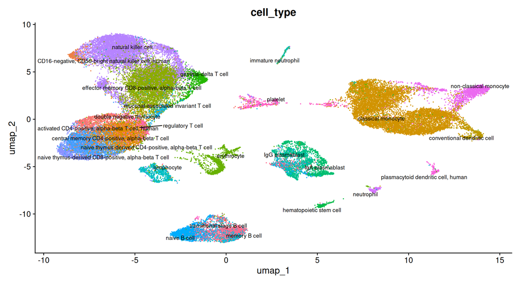

```r
DimPlot(object, reduction = "umap", group.by = "cell_type",
        label = TRUE, repel = TRUE, label.size = 3) + NoLegend()
```

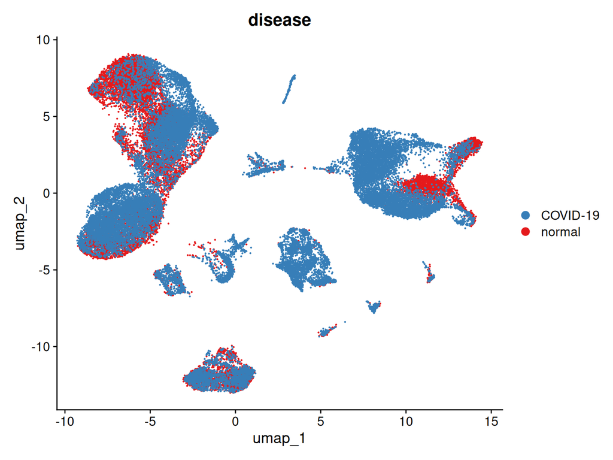

```r
DimPlot(object, reduction = "umap", group.by = "disease",
        cols = c("#377eb8", "#e41a1c"))
```

## Differential composition analysis

This is the section the workshop is here for.

We look for differences in the proportion of each cell type between healthy and COVID-19 donors. The recipe: cross-tabulate donor against cell type, drop donors with 50 or fewer cells, divide each donor’s row by its row total to get relative abundances, then attach each donor’s disease status.

```r
df_comp <- as.data.frame.matrix(table(object$donor_id, object$cell_type))
select.donors <- rownames(df_comp)[rowSums(df_comp) > 50]
df_comp <- df_comp[select.donors, ]
df_comp_relative <- sweep(x = df_comp, MARGIN = 1,
                          STATS = rowSums(df_comp), FUN = "/")

# This dataset splits plasmablasts into IgA and IgG subtypes. Collapse them into
# one Plasmablast column so the comparison matches the upstream story.
pb_cols <- grep("plasmablast", colnames(df_comp_relative),
                value = TRUE, ignore.case = TRUE)
df_comp_relative$Plasmablast <- rowSums(df_comp_relative[, pb_cols, drop = FALSE])

# The MAIT population is spelled out in this dataset's ontology labels.
mait_col <- "mucosal-associated invariant T cell"

df_disease <- as.data.frame.matrix(table(object$donor_id, object$disease))[select.donors, ]

df_comp_relative$disease <- "other"
df_comp_relative$disease[df_disease$normal != 0] <- "normal"
df_comp_relative$disease[df_disease$`COVID-19` != 0] <- "COVID-19"
df_comp_relative$disease <- factor(df_comp_relative$disease,
                                   levels = c("normal", "COVID-19", "other"))
df_comp_relative <- df_comp_relative |>
  dplyr::filter(disease %in% c("normal", "COVID-19"))
```

Note what the disease assignment does. A donor is labelled `normal` if any of its cells fall under `normal`, then relabelled `COVID-19` if any fall under `COVID-19`, so `COVID-19` wins for a donor with both. In this dataset each donor is one arm, so that is moot here, but it is the vignette’s own logic and worth keeping visible.

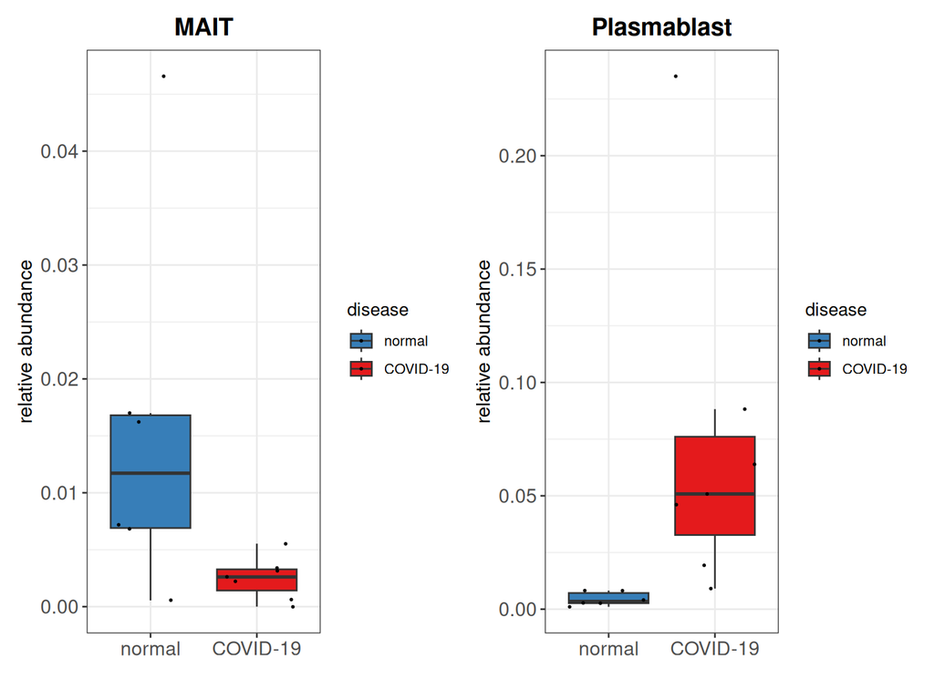

```r
plot_abundance <- function(df, column, title) {
  ggplot(df, aes(x = disease, y = .data[[column]], fill = disease)) +
    geom_boxplot(outlier.shape = NA) +
    geom_jitter(color = "black", size = 0.4, alpha = 0.9) +
    scale_fill_manual(values = c("#377eb8", "#e41a1c")) +
    xlab("") + ylab("relative abundance") + ggtitle(title) +
    theme_bw() +
    theme(axis.title = element_text(size = 12),
          axis.text = element_text(size = 12),
          plot.title = element_text(size = 15, hjust = 0.5, face = "bold"))
}

p1 <- plot_abundance(df_comp_relative, mait_col, "MAIT")
p2 <- plot_abundance(df_comp_relative, "Plasmablast", "Plasmablast")
p1 + p2 + plot_layout(ncol = 2)
```

MAIT cells are reduced and plasmablasts increased in COVID-19, the same result the upstream vignette reports. **And, like upstream, that is where it stops. Two boxplots, no test.**

## Optional: add the test the vignette omits

`propeller` turns these per-donor proportions into a real result with an FDR attached, in about three lines. It is a good place to make the point that the boxplots above are a picture, not an analysis.

Phipson et al. 2022, “propeller: testing for differences in cell type proportions in single cell data”, Bioinformatics, https://doi.org/10.1093/bioinformatics/btac582

```r
# Not run by default, needs the speckle package. Remove eval:false to run it.
library(speckle)
propeller(clusters = object$cell_type,
          sample   = object$donor_id,
          group    = object$disease)
```

## Differential expression analysis

Beyond composition, an aggregation-based (pseudobulk) workflow looks at differential genes between healthy and COVID-19 donors. All cells sharing a cell type and a donor are aggregated with `AggregateExpression`, giving one profile per cell type per donor.

```r
bulk <- AggregateExpression(object,
  return.seurat = TRUE,
  assays  = "RNA",
  group.by = c("cell_type", "donor_id", "disease"))

bulk <- subset(bulk, subset = disease %in% c("normal", "COVID-19"))
bulk$disease <- factor(bulk$disease, levels = c("normal", "COVID-19"))
```

With the pseudobulk object in hand, we can look at interferon-stimulated genes, which are typically upregulated during viral infection. As upstream does, this only visualizes them, it does not test.

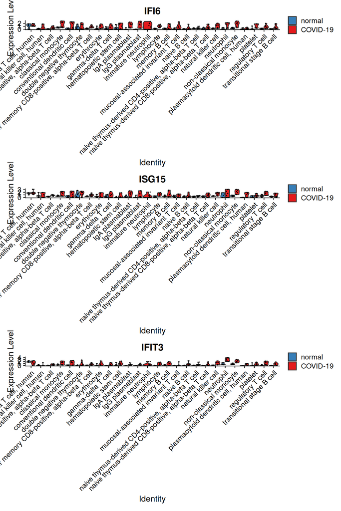

```r
p1 <- VlnPlot(bulk, features = "IFI6", group.by = "cell_type",
              split.by = "disease", cols = c("#377eb8", "#e41a1c"))
p2 <- VlnPlot(bulk, features = "ISG15", group.by = "cell_type",
              split.by = "disease", cols = c("#377eb8", "#e41a1c"))
p3 <- VlnPlot(bulk, features = "IFIT3", group.by = "cell_type",
              split.by = "disease", cols = c("#377eb8", "#e41a1c"))
p1 + p2 + p3 + plot_layout(ncol = 1)
```

Like the composition section, this stops at pictures. The violins are split by disease and no test is run on them either.